# QTM 151 - Quiz 1

## Try to submit as an HTML file

Print your name below

```python
# Write your own code
print("Daisy Cossio Garcia")
```

```
Daisy Cossio Garcia
```

This quiz is open book

- You can use the lecture notes
- You will get partial credit for attempting the questions
- To get full credit, the code should run as intended
- You should NOT communicate with other students

Print the following message:

"I will abide by Emory's code of conduct"

```python
# Write your own code
print("I will abide by Emory's code of conduct")
```

```
I will abide by Emory's code of conduct
```

Import the libraries "numpy", "matplotlib.pytplot", and "pandas"

```python
# Write your own code
import numpy as np
import matplotlib.pyplot as plt
import pandas as pd
```

## Part I: Visualizing random variables

(a) Create two random variables ...

- Call them "vec_x" and "vec_z"
- Generate "vec_x" from a uniform distribution with (low = 10, high = 20, size = 1000)
- Generate "vec_z" from a chi-square distribution with (df = 1, size = 1000)
- Plot a histogram of each variable
  - Label the axes and title
  - Each graph should have a different title

To get full points, plot the histograms on a grid (See Lecture 6)

[figure not shown]

```python
# Write your own code
vec_x    = np.random.uniform(low = 10 ,high = 20, size = 1000)
vec_z    = np.random.chisquare(df = 1, size = 1000)

fig, list_subfig = plt.subplots(1, 2,figsize = (6,3))
plt.tight_layout()
# First Figure
list_subfig[0].hist(x = vec_x)
list_subfig[0].set_title("Normal Distribution of Vec X")
list_subfig[0].set_xlabel("Value")
list_subfig[0].set_ylabel("Frequency")
# Second Figure
list_subfig[1].hist(x = vec_z)
list_subfig[1].set_title("Uniform Distribution of Vec Z")
list_subfig[1].set_xlabel("Value")
list_subfig[1].set_ylabel("Frequency")

# 4
```

(b) Create a new variable "vec_y" by the formula

$ y = e^x + 2x + 5$

- Use element-by-element vector operations (no loops)
- Produce a scatter plot of "vec_y" against "vec_x"
- Label the axes and the title
- Change the color to "red", "green" or "purple" (you choose)

Hint: You can use the numpy "exp()" function with vector arrays

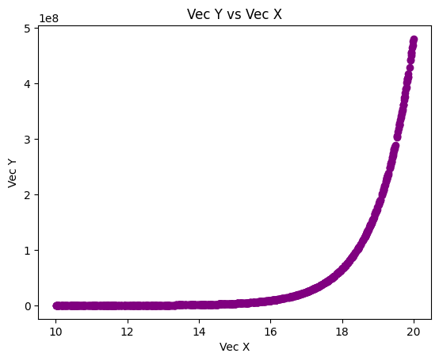

```python
# Write your own code

vec_y = np.e**vec_x + 2 * vec_x + 5
plt.scatter ( x =vec_x, y =vec_y, color = "purple")
plt.title ("Vec Y vs Vec X" )
plt.xlabel ("Vec X")
plt.ylabel ("Vec Y")
```

## Part II: Operations over multiple datasets

(c) Create two lists with ...

- The names of the datasets
- The years of the datasets (type manually based on the dataset names)

To answer this question, you need to browse the Quiz folder

You will find three datasets on the distribution of ages worldwide

```python
# Write your own code
wdi_1980 = pd.read_csv("data_quiz/wdi_ages1980.csv")
wdi_2000 = pd.read_csv("data_quiz/wdi_ages2000.csv")
wdi_2020 = pd.read_csv("data_quiz/wdi_ages2020.csv")

list_wdi1 = [wdi_1980, wdi_2000, wdi_2020]
list_wdi2 = [wdi_1980, wdi_2000, wdi_2020]

wdi_1980.name = "WDI Ages 1980"
wdi_2000.name = "WDI Ages 2000"
wdi_2020.name = "WDI Ages 2020"
```

(d) Create a loop that ...

- Goes over the list of years
- If the year $\ge$ 2000, print the message

$\qquad$ "This dataset contains information on or after 2000.

- If the year $<$ 2000, print the message

$\qquad$ "This dataset contains information before 2000"

```python
# Write your own code

dataset_years = 2000 #just my testing variable

if dataset_years >= 2000:
    print("This dataset contains information on or after 2000")
else:
    print("This dataset contains information before 2000")
```

```
This dataset contains information on or after 2000
```

(e) Your goal is to convert all the ".csv" data files to ".xlsx" (Excel) files

- Create a list with the ".csv" dataset names (including their relative subfolder "data_quiz/)
- Create a new list called "list_newnames", with each element ending in ".xlsx" (including the subfolder "data_excel/")
- Start an index

$\qquad$ index = 0

- Initiate a for-loop over the list of dataset names. Inside the loop:
  - Read the ".csv" dataset and store it in an object called "dataset"
  - Create a variable called "filename" from the "list_newnames", extracting the element "index"
  - Store "dataset" as an excel file with name "filename".

  $\qquad$ index = index + 1

Note: Check that you did it correctly by trying to open your new excel files outside "VSCode"

```python
# Write your own code

list_wdi_csv = [wdi_1980, wdi_2000, wdi_2020]
list_newnames = ["data_excel/wdi_1980.xlsx", "data_excel/wdi_1980.xlsx", "data_excel/wdi_1980.xlsx"]
index = 0

for dataset in list_wdi_csv:
    print( filename = list_newnames +str(index)
       filename = dataset)
    index = index + 1

# Wasn't able to figure it out
```

```
  Cell In[28], line 8
    print( filename = list_newnames +str(index)
                      ^
SyntaxError: invalid syntax. Perhaps you forgot a comma?
```

(f) Your goal is to open each dataset, create a new variable, then plot

- Create a list with the ".csv" dataset names (including their relative subfolder "data_quiz/)
- Start an index

$\qquad$ index = 0

- Initiate a for loop over the list of dataset names. Inside the loop:
  - Read the dataset and store it in an object called "dataset"
  - Create two new variables as

  $\qquad$ percent_ages0to14 = dataset["percent_ages0to14"]  
  $\qquad$ percent_ages15to64 = dataset["percent_ages15to64"]
  - Calculate the percent of the population between ages 0 and 64 by adding the two previous variables
  - Plot a histogram and label the axes
  - Use plt.show() to display the plot
  - Write

  $\qquad$ index = index + 1

This should produce a histogram for each dataset

```python
# Write your own code
```